# PS-1 Markdown

# Section 2: Linear Transformation of Images

### 2.1: Rotate Matrices

1. Rotate Matrix A

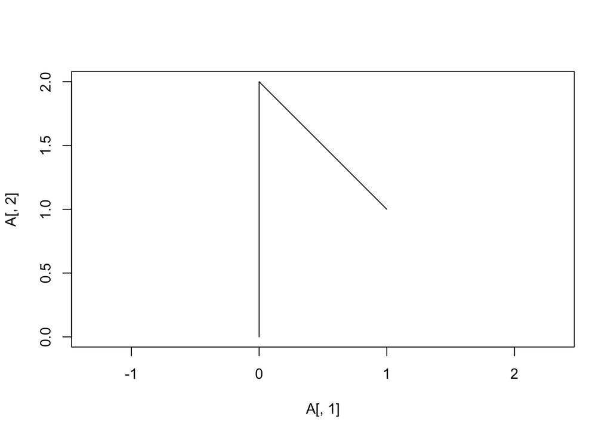

```r
A <- matrix(c(0,0, 0,2, 1,1), 3, 2, byrow = TRUE)
plot(A[,1], A[,2], type ="l", asp=1)
```

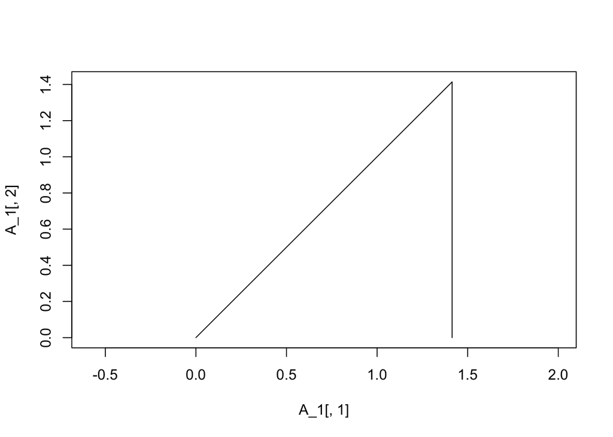

```r
Rot <- function(alpha) {
  a <- alpha*pi/180
  matrix(c(cos(a), sin(a), -sin(a), cos(a)), 2, 2)
}

A_1 <- A%*%Rot(45)
plot(A_1[,1], A_1[,2], type ="l", asp=1)
```

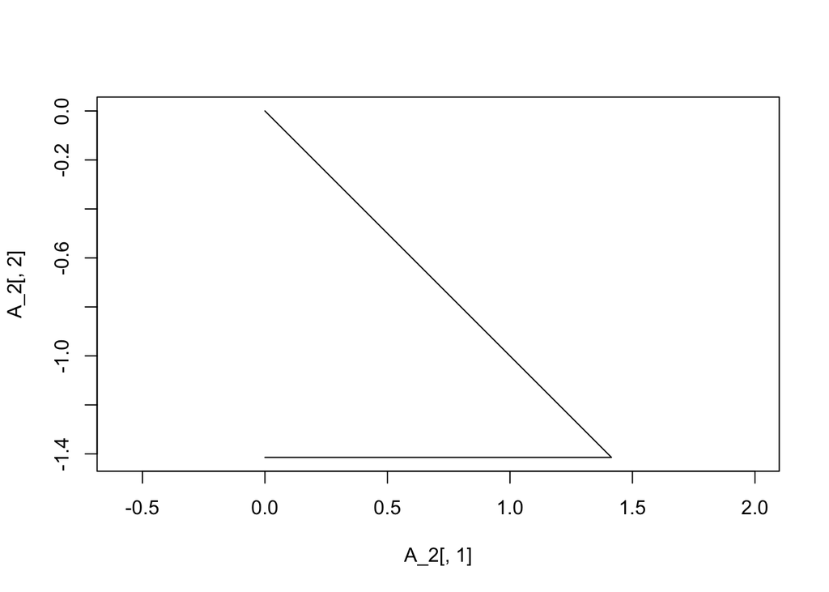

```r
A_2 <- A%*%Rot(-225)
plot(A_2[,1], A_2[,2], type ="l", asp=1)
```

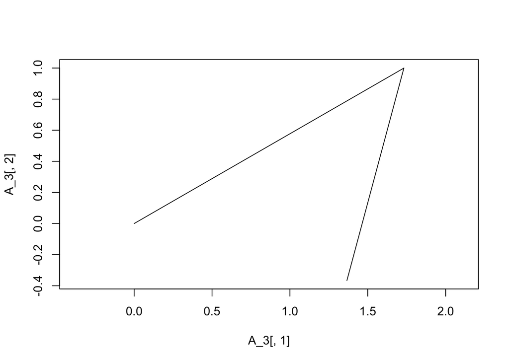

```r
A_3 <- A%*%Rot(60)
plot(A_3[,1], A_3[,2], type ="l", asp=1)
```

2. Create new matrix object “B”

```r
B <- matrix(c(2,3, 5,6, 10,-12), 3, 2, byrow = TRUE)
B
```

```
##      [,1] [,2]
## [1,]    2    3
## [2,]    5    6
## [3,]   10  -12
```

3. Rotate Matrix B

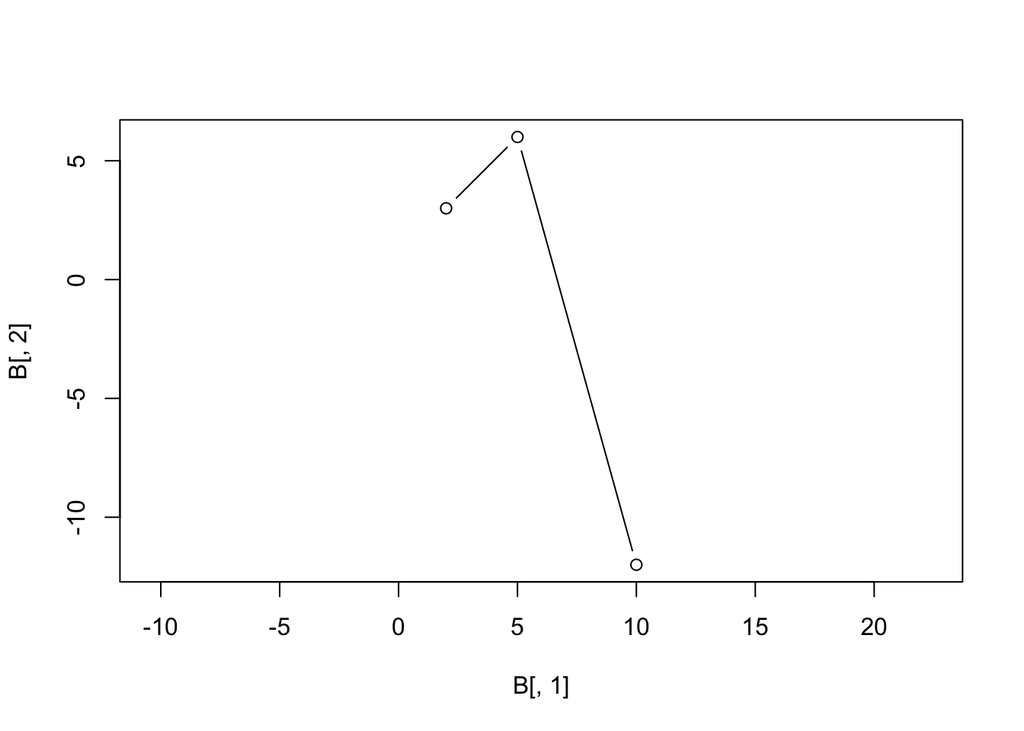

```r
plot(B[,1], B[,2], type="b", asp=1 )
```

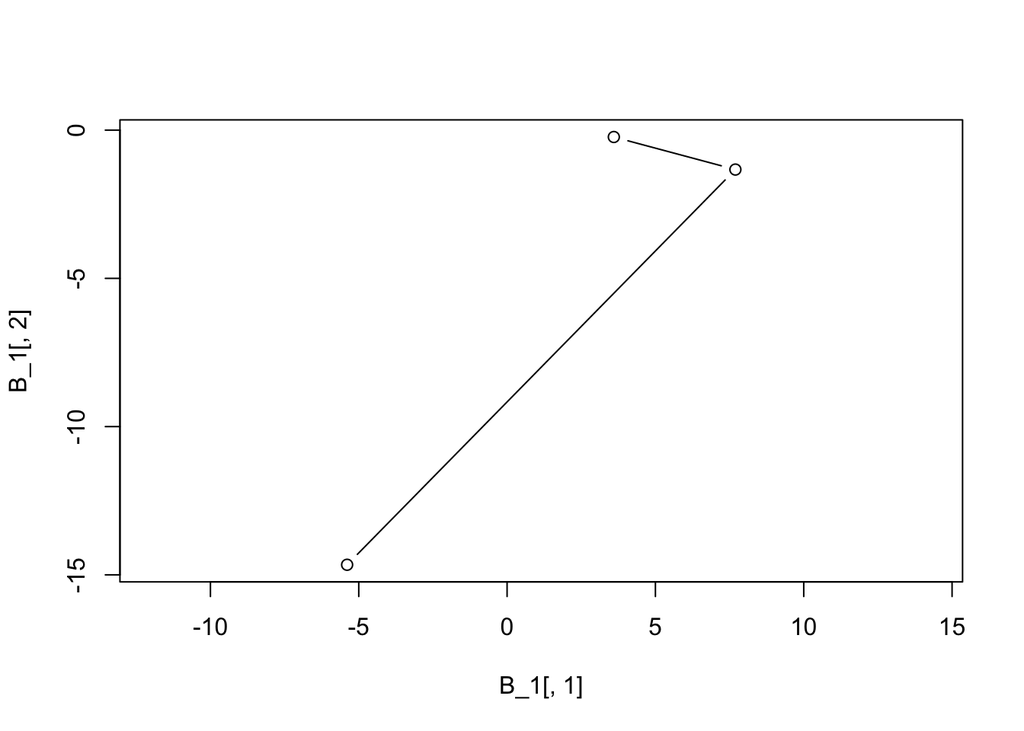

```r
B_1 <- B%*%Rot(60)
plot(B_1[,1], B_1[,2], type="b", asp=1)
```

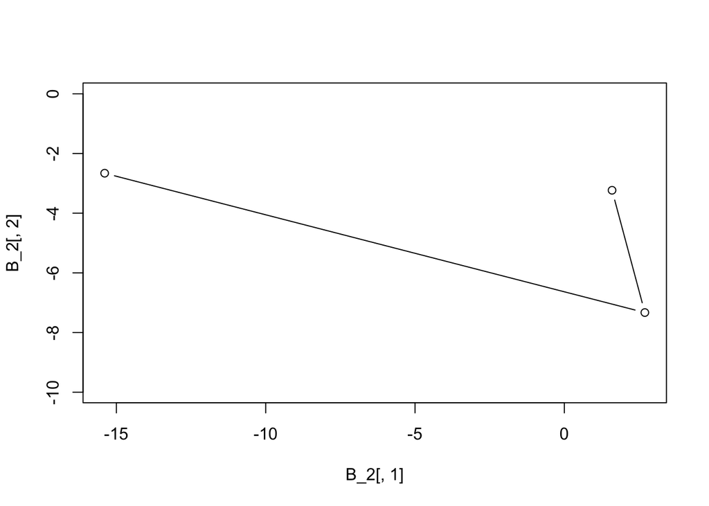

```r
B_2 <- B%*%Rot(120)
plot(B_2[,1], B_2[,2], type="b", asp=1)
```

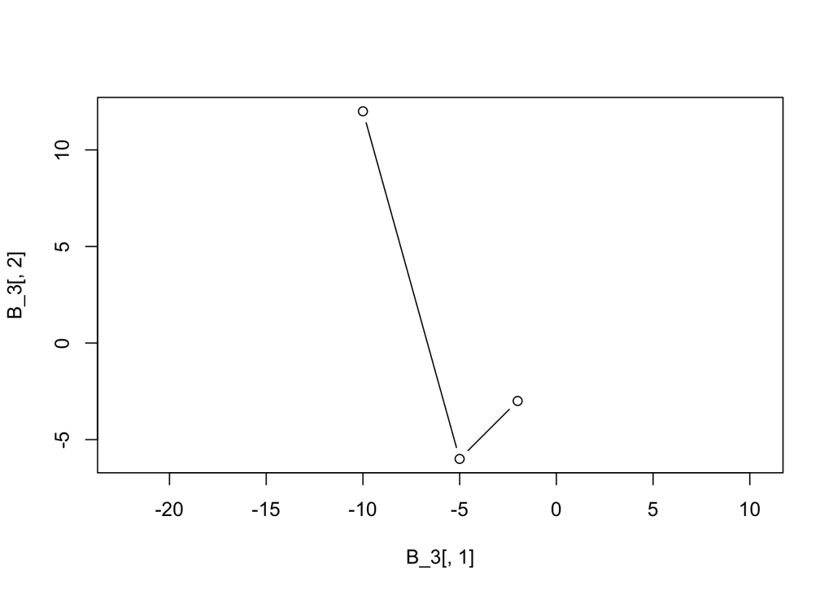

```r
B_3 <- B%*%Rot(-180)
plot(B_3[,1], B_3[,2], type="b", asp=1)
```

### 2.2: Rotate Data

1. Read in Crazy Hat file

```r
setwd("/Users/nicolebohra/INFO371")
data <- read.table('crazy_hat.tsv', header = TRUE)
```

2. Plot graph and connect lines

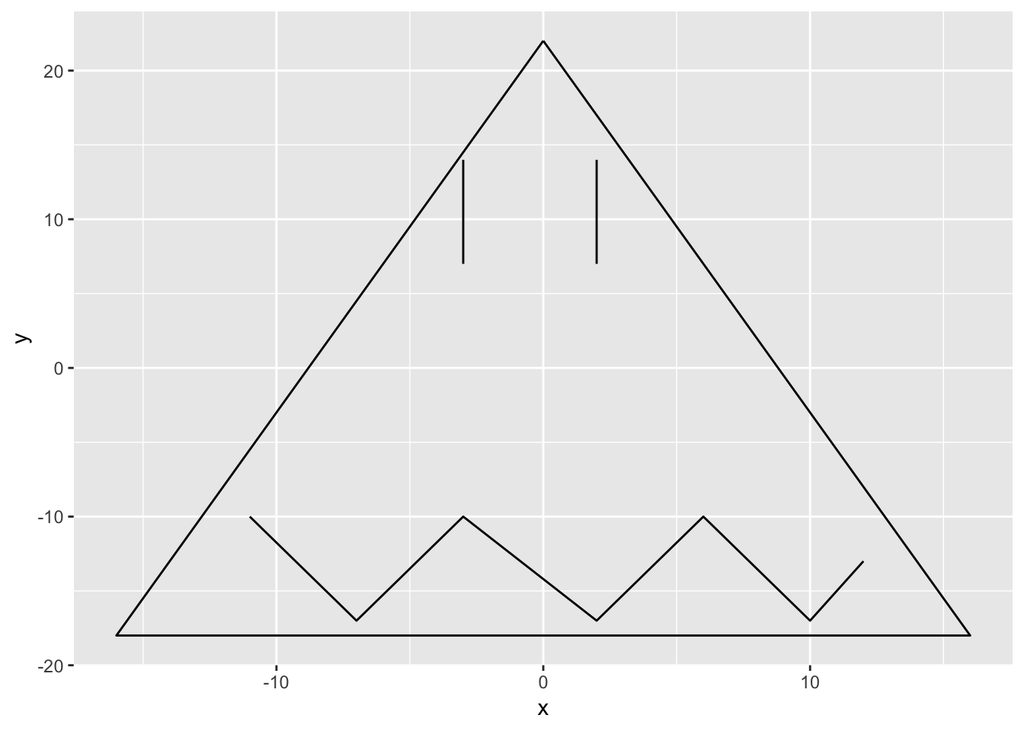

```r
ggplot(data, aes(x = x, y = y, group = group)) + geom_path()
```

3. Rotate Crazy Hat matrix object

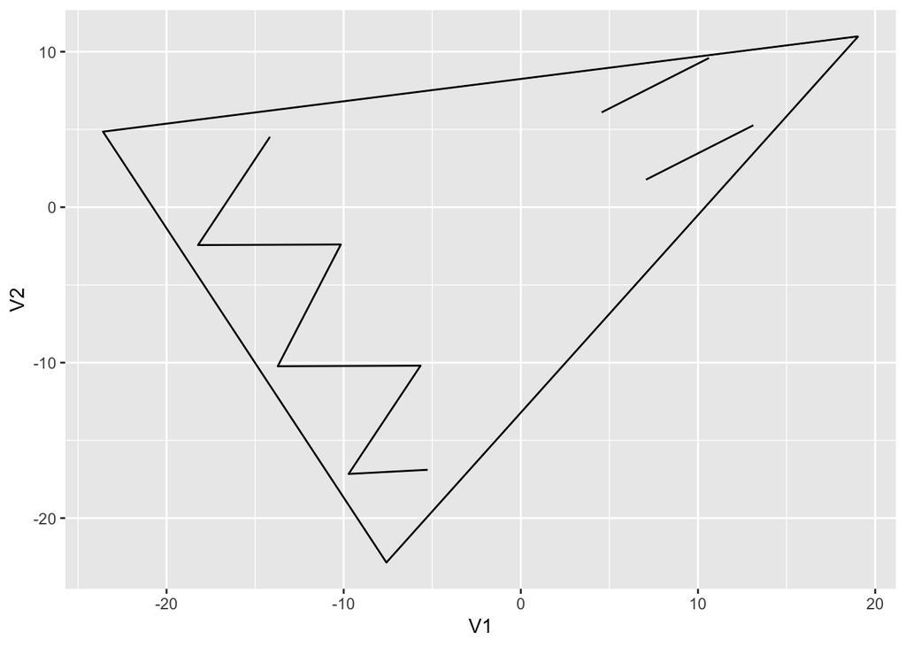

```r
mat <- data.matrix(data)
Rot <- function(alpha) {
  a <- alpha*pi/180
  matrix(c(cos(a), sin(a), -sin(a), cos(a)), 2, 2)
}
transMatrix1 <- mat[,1:2]%*%Rot(60)
transMatrix1.df <- cbind(transMatrix1[,1:2], mat[,3])
transMatrix1.df <- as.data.frame(transMatrix1.df)
ggplot(transMatrix1.df, aes(x = V1, y = V2, group = V3)) + geom_path()
```

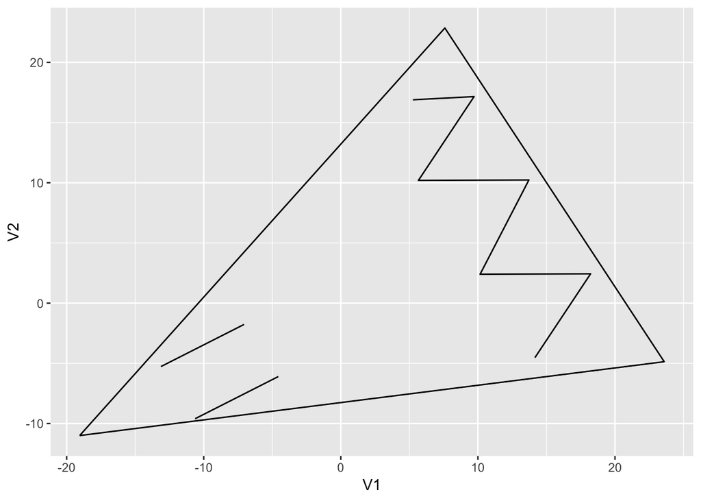

```r
transMatrix2 <- mat[,1:2]%*%Rot(-120)
transMatrix2.df <- cbind(transMatrix2[,1:2], mat[,3])
transMatrix2.df <- as.data.frame(transMatrix2.df)
ggplot(transMatrix2.df, aes(x=V1, y = V2, group = V3)) + geom_path()
```

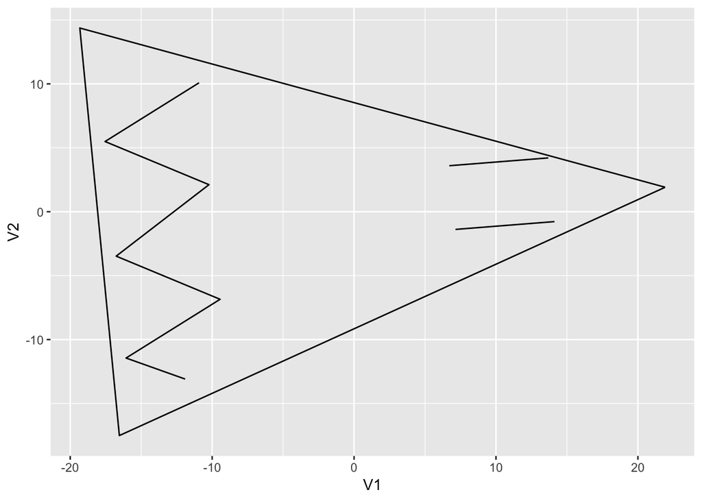

```r
transMatrix3 <- mat[,1:2]%*%Rot(85)
transMatrix3.df <- cbind(transMatrix3[,1:2], mat[,3])
transMatrix3.df <- as.data.frame(transMatrix3.df)
ggplot(transMatrix3.df, aes(x=V1, y = V2, group = V3)) + geom_path()
```

### 2.3: Flip and Stretch

1. Flip matrix over y-axis

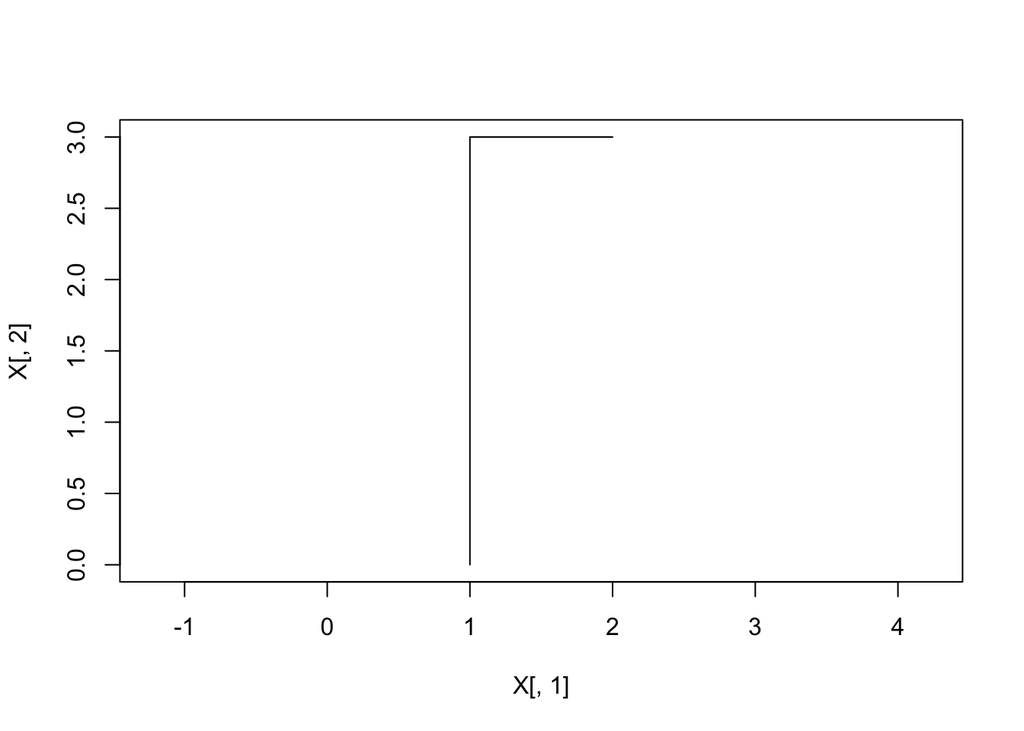

```r
X <- matrix(c(1,0, 1,3, 2,3), 3, 2, byrow = TRUE)
plot(x = X[,1], y =X[,2], type="l", asp=1)
```

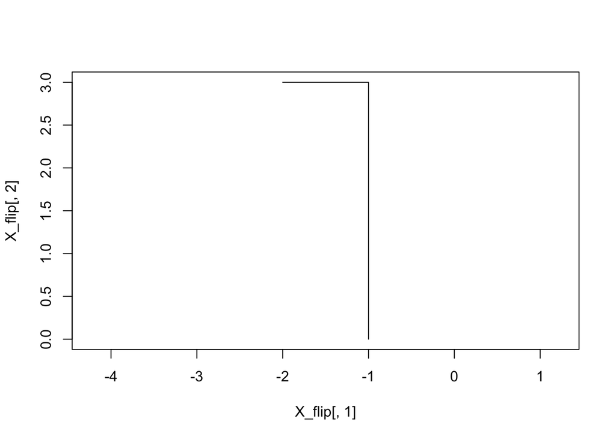

```r
X_flip<- X%*%matrix(c(-1, 0, 0, 1), 2, 2)
plot(X_flip[,1], X_flip[,2], type="l", asp=1)
```

2. Stretch matrix object

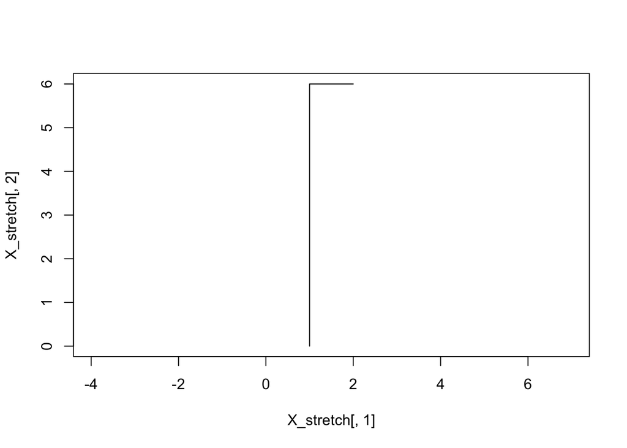

```r
X_stretch <- X%*%matrix(c(1, 0, 0, 2), 2, 2)
plot(X_stretch[,1], X_stretch[,2], type="l", asp=1)
```

3. Transform Crazy Hat object

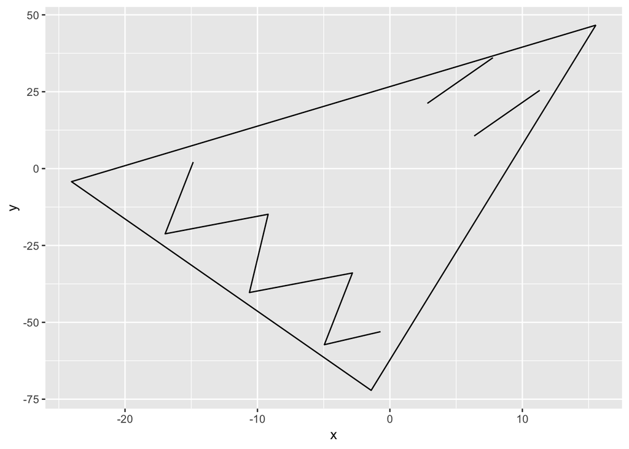

```r
flipStretchMatrix <- function(mat, alpha, stretchFactor){
  mat <- mat[,1:2] %*% Rot(alpha)
  mat[,2] <- mat[,2] * stretchFactor
  return(mat)
}
flipStretchData <- function(data, alpha, stretchFactor){
  matrix_flip <- data.matrix(data)
  matrix_flip <- flipStretchMatrix(matrix_flip, alpha, stretchFactor)
  data$x <- matrix_flip[,1]
  data$y <- matrix_flip[,2]
  ggplot(data, aes(x, y, group=group)) + geom_path()
}
flipStretchData(data, 45, 3)
```

4. To modify the matrix in which post-multiply and pre-multiply outputs the same result, a conversion using the transpose function would yield the same result. The equivalent to (AB) would be to multiply the transposed B by transposed A and transpose the entire result. The equation would look like: A x B = (B’ x A’)’.